# Reproducible Research: Peer Assessment 1

## Loading and preprocessing the data

First we set the locale to english

```r
Sys.setlocale("LC_TIME", "C")
```

then we load and cache the data

```r
data <- read.csv("./activity.csv")
```

and finally we preprocess the data

```r
data$realDate <- as.Date(data[, 'date'], format='%Y-%m-%d')
pdata <- subset(data, !is.na(steps))
```

## What is mean total number of steps taken per day?

We plot an histogram of the total number of steps taken each day

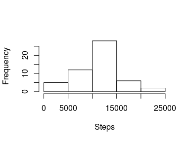

```r
stepsPerDay <- aggregate(pdata$steps, by=list(date=pdata$date), FUN=sum)
hist(stepsPerDay$x, xlab="Steps", main="")
```

We calculate the mean and the median

```r
mean1 <- format(mean(stepsPerDay$x, na.rm=T), nsmall=2)
median1 <- format(median(stepsPerDay$x, na.rm=T), nsmall=2)
```

The mean number of steps taken per day is around 10766.19.

The median is 10765.

## What is the average daily activity pattern?

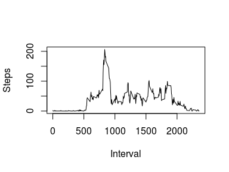

```r
stepsPerInterval <- aggregate(pdata$steps, by=list(interval=pdata$interval), FUN=mean)
plot(stepsPerInterval$interval, stepsPerInterval$x, type="l", xlab="Interval", ylab="Steps", main="")
```

On average the interval with the maximum number of steps is the number 835.

## Imputing missing values

```r
isnas <- sum(is.na(data$steps))
```

There are 2304 missing values (where the steps values is NA).

We can replace every NA value with the equivalent interval average.

```r
data$allSteps <- ifelse(is.na(data$steps), stepsPerInterval[match(data$interval, stepsPerInterval$interval), 'x'], data$steps)
```

We plot an histogram of the total number of steps taken each day

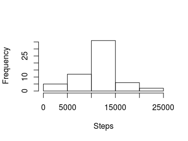

```r
allStepsPerDay <- aggregate(data$allSteps, by=list(date=data$date), FUN=sum)
hist(allStepsPerDay$x, xlab="Steps", main="")
```

We calculate the mean and the median

```r
mean2 <- format(mean(allStepsPerDay$x, na.rm=T), nsmall=2)
median2 <- format(median(allStepsPerDay$x, na.rm=T), nsmall=2)
```

The mean number of steps taken per day is around 10766.19.

The median is 10766.19.

## Are there differences in activity patterns between weekdays and weekends?

We split the data beased on the fact that the date is a weekday or a day of the weekend.

```r
data$weekday <- ifelse(weekdays(data$realDate, abbreviate=T) %in% c('Sat', 'Sun'), 'weekend', 'weekday')
weekdayData <- subset(data, weekday=='weekday')
weekendData <- subset(data, weekday=='weekend')
```

And we plot the data

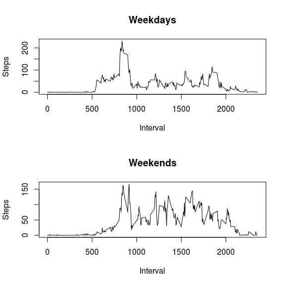

```r
stepsPerWeekdayInterval <- aggregate(weekdayData$allSteps, by=list(interval=weekdayData$interval), FUN=mean)
stepsPerWeekendInterval <- aggregate(weekendData$allSteps, by=list(interval=weekendData$interval), FUN=mean)
par(mfcol=c(2,1))
plot(stepsPerWeekdayInterval$interval, stepsPerWeekdayInterval$x, type="l", xlab="Interval", ylab="Steps", main="Weekdays")
plot(stepsPerWeekendInterval$interval, stepsPerWeekendInterval$x, type="l", xlab="Interval", ylab="Steps", main="Weekends")
```

It appears that during the weekend the steps count increases.